# LOP Manuscript Figures

Kirk Amundson

2019_1012

```r
library(tidyverse)
library(grid)
library(gridExtra)
library(MeanShift)
library(ggbeeswarm)
```

```r
files <- dir(path = "../experiments/2_low_cov_cnv/data/plots", pattern = "-dosage_plot.tsv", full.names = T)
files
```

```
  [1] "../experiments/2_low_cov_cnv/data/plots/2x_LOP868_004-dosage_plot.tsv"  "../experiments/2_low_cov_cnv/data/plots/2x_LOP868_005-dosage_plot.tsv"  "../experiments/2_low_cov_cnv/data/plots/2x_LOP868_006-dosage_plot.tsv"
  [4] "../experiments/2_low_cov_cnv/data/plots/2x_LOP868_011-dosage_plot.tsv"  "../experiments/2_low_cov_cnv/data/plots/2x_LOP868_012-dosage_plot.tsv"  "../experiments/2_low_cov_cnv/data/plots/2x_LOP868_015-dosage_plot.tsv"
  [7] "../experiments/2_low_cov_cnv/data/plots/2x_LOP868_016-dosage_plot.tsv"  "../experiments/2_low_cov_cnv/data/plots/2x_LOP868_025-dosage_plot.tsv"  "../experiments/2_low_cov_cnv/data/plots/2x_LOP868_026-dosage_plot.tsv"
 [10] "../experiments/2_low_cov_cnv/data/plots/2x_LOP868_027-dosage_plot.tsv"  "../experiments/2_low_cov_cnv/data/plots/2x_LOP868_028-dosage_plot.tsv"  "../experiments/2_low_cov_cnv/data/plots/2x_LOP868_029-dosage_plot.tsv"
 [13] "../experiments/2_low_cov_cnv/data/plots/2x_LOP868_030-dosage_plot.tsv"  "../experiments/2_low_cov_cnv/data/plots/2x_LOP868_034-dosage_plot.tsv"  "../experiments/2_low_cov_cnv/data/plots/2x_LOP868_037-dosage_plot.tsv"
 [16] "../experiments/2_low_cov_cnv/data/plots/2x_LOP868_041-dosage_plot.tsv"  "../experiments/2_low_cov_cnv/data/plots/2x_LOP868_042-dosage_plot.tsv"  "../experiments/2_low_cov_cnv/data/plots/2x_LOP868_043-dosage_plot.tsv"
 [19] "../experiments/2_low_cov_cnv/data/plots/2x_LOP868_044-dosage_plot.tsv"  "../experiments/2_low_cov_cnv/data/plots/2x_LOP868_045-dosage_plot.tsv"  "../experiments/2_low_cov_cnv/data/plots/2x_LOP868_046-dosage_plot.tsv"
 [22] "../experiments/2_low_cov_cnv/data/plots/2x_LOP868_048-dosage_plot.tsv"  "../experiments/2_low_cov_cnv/data/plots/2x_LOP868_058-dosage_plot.tsv"  "../experiments/2_low_cov_cnv/data/plots/2x_LOP868_060-dosage_plot.tsv"
 [25] "../experiments/2_low_cov_cnv/data/plots/2x_LOP868_062-dosage_plot.tsv"  "../experiments/2_low_cov_cnv/data/plots/2x_LOP868_064-dosage_plot.tsv"  "../experiments/2_low_cov_cnv/data/plots/2x_LOP868_065-dosage_plot.tsv"
 [28] "../experiments/2_low_cov_cnv/data/plots/2x_LOP868_072-dosage_plot.tsv"  "../experiments/2_low_cov_cnv/data/plots/2x_LOP868_074-dosage_plot.tsv"  "../experiments/2_low_cov_cnv/data/plots/2x_LOP868_076-dosage_plot.tsv"
 [31] "../experiments/2_low_cov_cnv/data/plots/2x_LOP868_077-dosage_plot.tsv"  "../experiments/2_low_cov_cnv/data/plots/2x_LOP868_079-dosage_plot.tsv"  "../experiments/2_low_cov_cnv/data/plots/2x_LOP868_081-dosage_plot.tsv"
 [34] "../experiments/2_low_cov_cnv/data/plots/2x_LOP868_086-dosage_plot.tsv"  "../experiments/2_low_cov_cnv/data/plots/2x_LOP868_088-dosage_plot.tsv"  "../experiments/2_low_cov_cnv/data/plots/2x_LOP868_090-dosage_plot.tsv"
 [37] "../experiments/2_low_cov_cnv/data/plots/2x_LOP868_097-dosage_plot.tsv"  "../experiments/2_low_cov_cnv/data/plots/2x_LOP868_108-dosage_plot.tsv"  "../experiments/2_low_cov_cnv/data/plots/2x_LOP868_1157-dosage_plot.tsv"
 [40] "../experiments/2_low_cov_cnv/data/plots/2x_LOP868_116-dosage_plot.tsv"  "../experiments/2_low_cov_cnv/data/plots/2x_LOP868_1160-dosage_plot.tsv" "../experiments/2_low_cov_cnv/data/plots/2x_LOP868_117-dosage_plot.tsv"
 [43] "../experiments/2_low_cov_cnv/data/plots/2x_LOP868_1180-dosage_plot.tsv" "../experiments/2_low_cov_cnv/data/plots/2x_LOP868_119-dosage_plot.tsv"  "../experiments/2_low_cov_cnv/data/plots/2x_LOP868_1190-dosage_plot.tsv"
```

[output cut: 42 more lines]

```r
all_dosage <- files %>%
  map(read_delim, delim = " ", col_names = T)
for (i in 1:length(files)) {
  all_dosage[[i]]$sample <- str_replace(files[i], "../experiments/2_low_cov_cnv/data/plots/", "")
  all_dosage[[i]]$sample <- gsub("-dosage_plot.tsv", "", all_dosage[[i]]$sample)
  all_dosage[[i]]$sample_num <- i
}
bin_dosage <- all_dosage %>%
  bind_rows() %>%
  mutate(sample = str_replace(sample, "-dosage_plot.tsv", "")) %>%
  filter(sample != "2x_LOP868_279")
chrom_dosage <- bin_dosage %>%
  group_by(chrom, sample, sample_num) %>%
  summarize(chrom_readcount = sum(readcount)) %>%
  arrange(sample, chrom) %>%
  filter(!is.na(chrom)) %>%
  ungroup()
```

```r
names(all_dosage) <- str_extract(files, "[24]x_.+") %>%
  str_remove("-dosage_plot.tsv")
names(all_dosage)
```

```
  [1] "2x_LOP868_004"  "2x_LOP868_005"  "2x_LOP868_006"  "2x_LOP868_011"  "2x_LOP868_012"  "2x_LOP868_015"  "2x_LOP868_016"  "2x_LOP868_025"  "2x_LOP868_026"  "2x_LOP868_027"  "2x_LOP868_028"  "2x_LOP868_029"  "2x_LOP868_030"  "2x_LOP868_034"  "2x_LOP868_037"  "2x_LOP868_041"
 [17] "2x_LOP868_042"  "2x_LOP868_043"  "2x_LOP868_044"  "2x_LOP868_045"  "2x_LOP868_046"  "2x_LOP868_048"  "2x_LOP868_058"  "2x_LOP868_060"  "2x_LOP868_062"  "2x_LOP868_064"  "2x_LOP868_065"  "2x_LOP868_072"  "2x_LOP868_074"  "2x_LOP868_076"  "2x_LOP868_077"  "2x_LOP868_079"
 [33] "2x_LOP868_081"  "2x_LOP868_086"  "2x_LOP868_088"  "2x_LOP868_090"  "2x_LOP868_097"  "2x_LOP868_108"  "2x_LOP868_1157" "2x_LOP868_116"  "2x_LOP868_1160" "2x_LOP868_117"  "2x_LOP868_1180" "2x_LOP868_119"  "2x_LOP868_1190" "2x_LOP868_1192" "2x_LOP868_1196" "2x_LOP868_122"
 [49] "2x_LOP868_123"  "2x_LOP868_124"  "2x_LOP868_126"  "2x_LOP868_128"  "2x_LOP868_131"  "2x_LOP868_171"  "2x_LOP868_172"  "2x_LOP868_198"  "2x_LOP868_204"  "2x_LOP868_205"  "2x_LOP868_219"  "2x_LOP868_220"  "2x_LOP868_222"  "2x_LOP868_224"  "2x_LOP868_227"  "2x_LOP868_234"
 [65] "2x_LOP868_236"  "2x_LOP868_238"  "2x_LOP868_244"  "2x_LOP868_247"  "2x_LOP868_248"  "2x_LOP868_251"  "2x_LOP868_254"  "2x_LOP868_255"  "2x_LOP868_256"  "2x_LOP868_257"  "2x_LOP868_258"  "2x_LOP868_259"  "2x_LOP868_262"  "2x_LOP868_267"  "2x_LOP868_268"  "2x_LOP868_269"
 [81] "2x_LOP868_270"  "2x_LOP868_272"  "2x_LOP868_273"  "2x_LOP868_274"  "2x_LOP868_278"  "2x_LOP868_279"  "2x_LOP868_280"  "2x_LOP868_281"  "2x_LOP868_286"  "2x_LOP868_289"  "2x_LOP868_292"  "2x_LOP868_293"  "2x_LOP868_295"  "2x_LOP868_299"  "2x_LOP868_304"  "2x_LOP868_305"
 [97] "2x_LOP868_306"  "2x_LOP868_308"  "2x_LOP868_309"  "2x_LOP868_311"  "2x_LOP868_313"  "2x_LOP868_349"  "2x_LOP868_361"  "2x_LOP868_363"  "2x_LOP868_365"  "2x_LOP868_372"  "2x_LOP868_373"  "2x_LOP868_387"  "2x_LOP868_396"  "2x_LOP868_397"  "2x_LOP868_398"  "2x_LOP868_401"
[113] "2x_LOP868_403"  "2x_LOP868_406"  "2x_LOP868_407"  "2x_LOP868_414"  "2x_LOP868_415"  "2x_LOP868_417"  "2x_LOP868_420"  "2x_LOP868_421"  "2x_LOP868_425"  "2x_LOP868_428"  "2x_LOP868_429"  "2x_LOP868_430"  "2x_LOP868_433"  "2x_LOP868_435"  "2x_LOP868_439"  "2x_LOP868_449"
[129] "2x_LOP868_450"  "2x_LOP868_452"  "2x_LOP868_454"  "2x_LOP868_456"  "2x_LOP868_459"  "2x_LOP868_460"  "2x_LOP868_461"  "2x_LOP868_463"  "2x_LOP868_464"  "2x_LOP868_465"  "2x_LOP868_466"  "2x_LOP868_467"  "2x_LOP868_469"  "2x_LOP868_473"  "2x_LOP868_474"  "2x_LOP868_477"
[145] "2x_LOP868_479"  "2x_LOP868_480"  "2x_LOP868_483"  "2x_LOP868_485"  "2x_LOP868_487"  "2x_LOP868_488"  "2x_LOP868_493"  "2x_LOP868_494"  "2x_LOP868_497"  "2x_LOP868_499"  "2x_LOP868_500"  "2x_LOP868_502"  "2x_LOP868_505"  "2x_LOP868_509"  "2x_LOP868_510"  "2x_LOP868_513"
[161] "2x_LOP868_514"  "2x_LOP868_522"  "2x_LOP868_523"  "2x_LOP868_525"  "2x_LOP868_529"  "2x_LOP868_532"  "2x_LOP868_535"  "2x_LOP868_538"  "4x_LOP868"
```

```r
with_totals <- chrom_dosage %>%
  group_by(sample, sample_num) %>%
  summarize(total_readcount = sum(chrom_readcount)) %>%
  left_join(chrom_dosage, .) %>%
  ungroup()
```

```r
with_control <- with_totals %>%
  filter(sample == "4x_LOP868") %>%
  mutate(chromshort = str_replace(chrom, "chr", "")) %>%
  mutate(chromshort = str_replace(chromshort, "^0", "")) %>%
  rename(control_chrom_readcount = chrom_readcount) %>%
  rename(control_total_readcount = total_readcount) %>%
  dplyr::select(-sample, -sample_num) %>%
  left_join(with_totals, .) %>%
  mutate(normcov = 2* (chrom_readcount / total_readcount) / (control_chrom_readcount / control_total_readcount)) %>%
  filter(!sample %in% c("4x_LOP868", "2x_LOP868_279"))
```

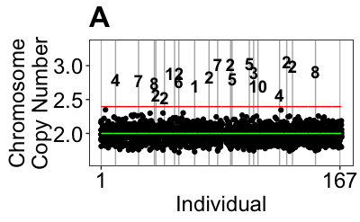

```r
fig2A <- with_control %>%
  filter(normcov <= mean(with_control$normcov + 3*sd(with_control$normcov))) %>%
  ggplot(., aes(x = sample_num, y = normcov)) +
  geom_vline(xintercept = c(with_control$sample_num[which(with_control$normcov >= mean(with_control$normcov) + 3 * sd(with_control$normcov))]), color = "gray70") +
  geom_point() +
  geom_text(data = filter(with_control, normcov >= mean(with_control$normcov) + 3*sd(with_control$normcov)), aes(x = sample_num, y = normcov, label = chromshort), size = 5, fontface = "bold") +
  geom_line(y = mean(with_control$normcov), color = "green") +
  geom_line(y = mean(with_control$normcov) + 3 * sd(with_control$normcov), color = "red") +
  scale_x_continuous(breaks = c(1,167), labels = c("1", "167")) +
  scale_y_continuous(limits = c(1.6, 3.3)) +
  ggtitle("A") +
  labs(x = "Individual", y = "Chromosome\nCopy Number") +
  theme_bw() +
  theme(panel.grid = element_blank(),
        panel.background=element_rect(fill="white",color="black"),
        axis.title.x=element_text(size=18),
        axis.title.y=element_text(size=18,angle= 90, vjust=0.5),
        plot.title=element_text(size=24,face="bold",hjust=0,color="black"),
        axis.text.x=element_text(size=18,color="black"),
        axis.text.y=element_text(size=18,color="black"),
        panel.grid.major.x = element_line(color = "gray70"))
fig2A
```

```r
# ggsave("Fig2A.pdf", plot=fig2A, width = 18, height = 3, units = "in", device = "pdf")
```

```r
chrom_overlay <- function(df, chr) {
  plt <- df %>%
    filter(chrom == chr) %>%
    filter(sample %in% trisomics) %>%
    filter(binsize >= 2.5e5) %>%
    ggplot(., aes(x = start, y = normcov, fill = sample)) +
    geom_line(aes(color = sample), size = 1) +
    geom_line(data = filter(df, chrom == chr & !sample %in% trisomics & binsize >= 2.5e5), aes(x = start, y = normcov, fill = sample), alpha = 0.2, size = 0.5) +
    facet_wrap(~chrom, strip.position = "r") +
    scale_x_continuous(breaks = seq(0,8e7,by=2e7), labels = seq(0,80,by=20)) +
    guides(fill = F, color = F) +
    labs(x = "Position (Mb)", y = "Standardized\nCoverage") +
    theme_bw() +
      theme(
      panel.grid.minor.x = element_blank(),
      panel.grid.minor.y = element_blank(),
      panel.grid.major.y = element_line(color="gray30", size = 0.2),
      panel.grid.major.x = element_blank(),
      strip.background = element_rect(fill = "white", color = "black"),
      panel.background = element_rect(fill = "white", color = "black"),
      axis.text = element_text(size = 14),
      axis.title = element_text(size = 16),
      strip.text = element_text(size = 14))
  return(plt)
  # print(plt)
  # ggsave(paste(chr, "_dosage_overlay.pdf", plot = plt, width = 6, height = 2, units = "in", device = "pdf")) # save these if needed
}
```

```r
fig3a <- chrom_overlay(bin_dosage, "chr01") + ggtitle("A")
```

Last part, do high coverage CNV here to finish Fig. S3

```r
# dps <- dir(path = "../..")
dp_cols <- c("chrom", "start", "end", "mean_dp", "median_dp")
dp_files <- dir(pattern = "summarized-depth", path = "../experiments/1_high_cov_variants/data/merged/", full.names = T)
dp <- dp_files %>%
  map(read_tsv, col_names = dp_cols)
sc <- rep(NA, length(dp_files))
for (i in 1:length(dp_files)) {
  dp[[i]] <- left_join(dp[[i]], read_tsv("../experiments/ref/GCN_10k_bin_potato_dm_v404_all_pm_un_chloro_mito.fasta", col_names = T))
  dp[[i]]$sample <- str_extract(dp_files[i], "[0-9]x_LOP868.+")
  dp[[i]]$gc_norm_dp <- dp[[i]]$median_dp / dp[[i]]$GC_content
  set.seed(5)
  mtx <- t(matrix(data = c(sample(na.omit(dp[[i]]$gc_norm_dp), 1000), rep(0,1000)), ncol=2))
  clusters <- msClustering(mtx, kernel = "epanechnikovKernel", h= quantile(dist(mtx[1,]), 0.25))
  sc[i] <- clusters$components[1,1]
}
```

```
Running mean-shift algorithm...
```

```
Mean-shift algorithm ran successfully.

Finding clusters...

The algorithm found 6 clusters.


Running mean-shift algorithm...
```

```
Mean-shift algorithm ran successfully.

Finding clusters...

The algorithm found 6 clusters.


Running mean-shift algorithm...
```

```
Mean-shift algorithm ran successfully.

Finding clusters...

The algorithm found 7 clusters.


Running mean-shift algorithm...
```

```
Mean-shift algorithm ran successfully.

Finding clusters...

The algorithm found 9 clusters.
```

```r
dp <- dp %>%
  bind_rows() %>%
  mutate(sample = str_remove(sample, ".tsv$"))
```

```r
fig_4a <- dp %>%
  filter(chrom == "chr06") %>%
  filter(N_content <= 0.3) %>%
  filter(sample == "4x_LOP868") %>%
  ggplot(., aes(x = start, y = gc_norm_dp)) +
  geom_point(alpha = 0.3, size = 0.8) +
  labs(x = "Position (Mb)", y = "Alca Tarma\nCopy Number") +
  ggtitle("A") +
  scale_y_continuous(limits = c(0, 220), breaks = c(0, sc[4]*.25, sc[4]*.5, sc[4]*0.75, sc[4], sc[4]*1.25, sc[4]*1.5, sc[4]*1.75, sc[4]*2), labels = c(0,1,2,3,4,5,6,7,8)) +
  scale_x_continuous(limits = c(0,6e7), breaks = seq(0, 6e7, by = 2e7), labels = seq(0, 60, by = 20)) +
  facet_wrap(~chrom, nrow = 12, strip.position = "right") +
  theme(
    panel.grid.major.x = element_blank(),
    panel.grid.minor.x = element_blank(),
    panel.grid.major.y = element_line(color = "gray30", size = 0.2),
    panel.grid.minor.y = element_blank(),
    panel.background = element_rect(fill = "white", color = "black"),
    axis.text = element_text(size = 14),
    axis.title = element_text(size = 16),
    strip.text = element_text(size = 14),
    plot.title = element_text(size = 24, face = "bold", hjust = -0.06, vjust = 2),
    strip.background = element_rect(fill = "white", color = "black")
  )
```

```
There were 12 warnings (use warnings() to see them)
```

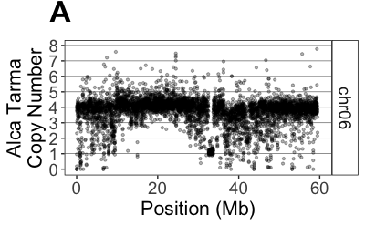

```r
fig_4a
```

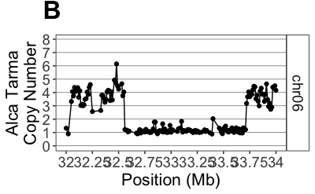

```r
fig_4b <- dp %>%
  filter(chrom == "chr06") %>%
  filter(start >= 3.2e7 & start <= 3.4e7) %>%
  filter(N_content <= 0.3) %>%
  filter(sample == "4x_LOP868") %>%
  ggplot(., aes(x = start, y = gc_norm_dp)) +
  geom_point() +
  geom_line() +
  labs(x = "Position (Mb)", y = "Alca Tarma\nCopy Number") +
  ggtitle("B") +
  scale_y_continuous(limits = c(0, 220), breaks = c(0, sc[4]*.25, sc[4]*.5, sc[4]*0.75, sc[4], sc[4]*1.25, sc[4]*1.5, sc[4]*1.75, sc[4]*2), labels = c(0,1,2,3,4,5,6,7,8)) +
  scale_x_continuous(breaks = seq(3.2e7, 3.4e7, by = 2.5e5), labels = seq(32,34,by=0.25)) +
  facet_wrap(~chrom, nrow = 12, strip.position = "right") +
  theme(
    panel.grid.major.x = element_blank(),
    panel.grid.minor.x = element_blank(),
    panel.grid.major.y = element_line(color = "gray30", size = 0.2),
    panel.grid.minor.y = element_blank(),
    panel.background = element_rect(fill = "white", color = "black"),
    axis.text = element_text(size = 14),
    axis.title = element_text(size = 16),
    strip.text = element_text(size = 14),
    plot.title = element_text(size = 24, face = "bold", hjust = -0.06, vjust = 2),
    strip.background = element_rect(fill = "white", color = "black")
  )
fig_4b
```

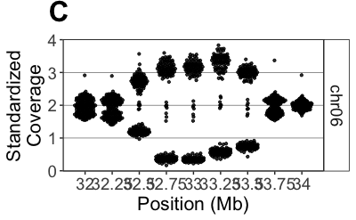

```r
fig_4c <- bin_dosage %>%
  filter(chrom == "chr06" & between(start, 3.2e7, 3.4e7)) %>%
  ggplot(., aes(x = start, y = normcov)) +
  geom_quasirandom(alpha = 0.8, size = 0.8) +
  guides(color = F) +
  labs(x = "Position (Mb)", y = "Standardized\nCoverage") +
  scale_x_continuous(breaks = seq(3.2e7,3.4e7,by=2.5e5), labels=seq(32,34,by=0.25)) +
  facet_wrap(~chrom, strip.position = "r") +
  ggtitle("C") +
  theme_bw() +
  theme(
    # axis.text.x = element_text(angle = 45, hjust = 1, vjust = 1),
    panel.grid.minor.x = element_blank(),
    panel.grid.minor.y = element_blank(),
    panel.grid.major.y = element_line(color="gray30", size = 0.2),
    panel.grid.major.x = element_blank(),
    strip.background = element_rect(fill = "white", color = "black"),
    panel.background = element_rect(fill = "white", color = "black"),
    axis.text = element_text(size = 14),
    axis.title = element_text(size = 16),
    plot.title = element_text(size = 24, face = "bold", hjust = -0.06, vjust = 2),
    strip.text = element_text(size = 14))
fig_4c
```

```r
fig_4d <- chrom_overlay(bin_dosage, "chr06") +
  ggtitle("D") +
  labs(x = "Position (Mb)", y = "Standardized\nCoverage") +
  theme(plot.title = element_text(size = 24, face = "bold", hjust = -0.06, vjust = 2))
```

```
Ignoring unknown aesthetics: fill
```

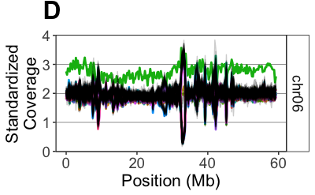

```r
fig_4d
```

[figure not shown]

```r
fig4 <- grid.arrange(fig_4a, fig_4b, fig_4c, fig_4d, nrow = 4)
```

```r
ggsave("Fig4.png", plot = fig4, width = 12, height = 12, units = "in", device = "png")
# ggsave("Fig4.pdf", plot = fig4, width = 12, height = 12, units = "in", device = "pdf")
```

```r
for (i in sprintf('chr%02d', 1:12)) {
  plt <- chrom_overlay(bin_dosage, i)
  dplt <- dp %>%
  filter(chrom == i) %>%
  filter(N_content <= 0.3) %>%
  filter(sample == "4x_LOP868") %>%
  ggplot(., aes(x = start, y = gc_norm_dp)) +
  geom_point(alpha = 0.3, size = 0.8) +
  labs(x = "", y = "Alca Tarma\nCopy Number") +
  # ggtitle("A") +
  scale_y_continuous(limits = c(0, 220), breaks = c(0, sc[4]*.25, sc[4]*.5, sc[4]*0.75, sc[4], sc[4]*1.25, sc[4]*1.5, sc[4]*1.75, sc[4]*2), labels = c(0,1,2,3,4,5,6,7,8)) +
  scale_x_continuous(limits = c(0,6e7), breaks = seq(0, 6e7, by = 2e7), labels = seq(0, 60, by = 20)) +
  facet_wrap(~chrom, nrow = 12, strip.position = "right") +
  theme(
    panel.grid.major.x = element_blank(),
    panel.grid.minor.x = element_blank(),
    panel.grid.major.y = element_line(color = "gray30", size = 0.2),
    panel.grid.minor.y = element_blank(),
    panel.background = element_rect(fill = "white", color = "black"),
    axis.text = element_text(size = 14),
    axis.title = element_text(size = 16),
    strip.text = element_text(size = 14),
    # plot.title = element_text(size = 24, face = "bold"),
    strip.background = element_rect(fill = "white", color = "black")
  )
  comb <- grid.arrange(dplt,plt)
  ggsave(paste0(i,"_figS3_combo_plot.png"), plot = comb, width = 9, height = 4, units = "in", device = "png")
}
```

Fig. S5

```r
names(sc) <- str_extract(dp_files, "LOP.+") %>%
  str_replace(., ".tsv", "") %>%
  str_replace(., "_", ".")
names(sc)
```

```r
overlay_emphasize_one <- function(df, dihap, chr) {
  plt <- df %>%
    filter(chrom == chr) %>%
    filter(sample != dihap) %>%
    filter(binsize >= 2.5e5) %>%
    ggplot(., aes(x = start, y = normcov, fill = sample)) +
    geom_line(alpha = 0.2) +
    geom_line(data = filter(df, chrom == chr & sample == dihap & binsize >= 2.5e5), color = "red", size = 1.2) +
    scale_x_continuous(breaks = seq(0,6e7,by=2e7), labels=seq(0,60,by=20)) +
    facet_wrap(~chrom, strip.position = "r") +
    labs(x = "Position (Mb)", y = "Standardized Coverage") +
    theme_bw() +
    theme(strip.background = element_rect(fill = "white", color = "black"),
          axis.text = element_text(size = 14),
          axis.title = element_text(size = 16),
          strip.text = element_text(size = 14),
          panel.grid.major.x = element_blank(),
          panel.grid.minor = element_blank())
  return(plt)
}

hicov <- function(df, dihap, chr, s, e) {

  sc_to_use <- dihap %>%
    str_remove("[24]x_") %>%
    str_replace(., "_", ".")
  # print(sc_to_use)

  sc_loc <- sc[which(names(sc) == sc_to_use)]

  plt <- df %>%
    filter(chrom == chr) %>%
    filter(between(start, s, e)) %>%
    filter(N_content <= 0.3) %>%
    filter(sample == dihap) %>%
    ggplot(., aes(x = start, y = gc_norm_dp)) +
    # geom_point() +
    # geom_line() +
    labs(x = "Position (Mb)", y = paste(sc_to_use, "Copy Number", sep = " ")) +
    facet_wrap(~chrom, strip.position = "r") +
    scale_x_continuous(breaks = seq(s,e, by = 2.5e5), labels = seq(s/1e6, e/1e6, by = 0.25)) +
    scale_y_continuous(limits = c(0, 2*sc_loc), breaks = c(0, 0.5*sc_loc, sc_loc, 1.5*sc_loc, 2*sc_loc), labels = seq(0,4)) +
    theme_bw() +
    theme(strip.background = element_rect(fill = "white", color = "black"),
          axis.text = element_text(size = 14),
          axis.title = element_text(size = 16),
          strip.text = element_text(size = 14),
          panel.grid.major.x = element_blank(),
          panel.grid.minor = element_blank())
  return(plt)
}
```

```r
s5_1 <- overlay_emphasize_one(bin_dosage, "2x_LOP868_004", "chr06")
s5_2 <- overlay_emphasize_one(bin_dosage, "2x_LOP868_064", "chr06")
s5_3 <- overlay_emphasize_one(bin_dosage, "2x_LOP868_305", "chr06")
s5_4 <- hicov(dp, "2x_LOP868_004", "chr06", 3.2e7, 3.4e7) + geom_point() + geom_line()
s5_5 <- hicov(dp, "2x_LOP868_064", "chr06", 3.2e7, 3.4e7) + geom_point() + geom_line()
s5_6 <- hicov(dp, "2x_LOP868_305", "chr06", 3.2e7, 3.4e7) + geom_point() + geom_line()
s5_7 <- hicov(dp, "2x_LOP868_004", "chr06", 0, 6e7) + geom_point(alpha = 0.3, size = 0.8) + scale_x_continuous(limits = c(0, 6e7), breaks = seq(0, 6e7, by = 2e7), labels = seq(0, 60, by = 20))
s5_8 <- hicov(dp, "2x_LOP868_064", "chr06", 0, 6e7) + geom_point(alpha = 0.3, size = 0.8) + scale_x_continuous(limits = c(0, 6e7), breaks = seq(0, 6e7, by = 2e7), labels = seq(0, 60, by = 20))
s5_9 <- hicov(dp, "2x_LOP868_305", "chr06", 0, 6e7) + geom_point(alpha = 0.3, size = 0.8) + scale_x_continuous(limits = c(0, 6e7), breaks = seq(0, 6e7, by = 2e7), labels = seq(0, 60, by = 20))
```

```r
s5 <- grid.arrange(s5_1, s5_2, s5_3, s5_4, s5_5, s5_6, s5_7, s5_8, s5_9, nrow = 3)
ggsave("Fig_S5.png", plot = s5, width = 18, height = 12, units = "in", device = "png")
```

Fig S4: Kernel density estimator plots illlustrating dosage variant clustering to get genotypes Note, red points were drawn in as manual points, using x values specified according to the cluster center, and the Y axis point drawn s/t it was at the peak of the kernel density function.

```r
kde_bin <- function(df, chr, s) {
  active_bin <- filter(df, chrom == chr & start == s) %>%
    mutate(bin = paste(chrom, start, end, sep = "_"))
  plt <- ggplot(active_bin, aes(x = normcov)) +
    geom_histogram(aes(y = ..density..), binwidth = 0.1, fill = "blue", alpha = 0.5) +
    geom_density(kernel = "ep", bw = quantile(dist(active_bin$normcov), 0.4)) +
    scale_x_continuous(limits = c(0,4)) +
    facet_wrap(~bin, strip.position = "r")
  return(plt)
}
```

```r
s4_1 <- kde_bin(bin_dosage, "chr01", 4.25e6)
s4_2 <- kde_bin(bin_dosage, "chr01", 2.425e7)
s4_3 <- kde_bin(bin_dosage, "chr01", 7.95e7)
ggsave("Fig_S4_1.png", plot = s4_1, width = 4, height = 2, units = "in", device = "png")
ggsave("Fig_S4_2.png", plot = s4_2, width = 4, height = 2, units = "in", device = "png")
ggsave("Fig_S4_3.png", plot = s4_3, width = 4, height = 2, units = "in", device = "png")
```

Fig. S6: Power analysis of rare indels in LOP dihaploid population. Note, I added the figure legend in Affinity Designer by copying the legend from figure s6_legend

```r
simhyb_les_alleles <- read_tsv("../experiments/3_fake_hybrids/indel_bin_alleles_simhyb.txt", col_names = T) %>%
  mutate(control_group = ifelse(grepl("SRR6123031", sample), "Simulated Alca Tarma x PL4",
                                ifelse(grepl("SRR6123183", sample), "Simulated Alca Tarma x IVP101", "Simulated Matrilineal"))) %>%
  mutate(control_group = factor(control_group, levels = c("Simulated Matrilineal", "Simulated Alca Tarma x IVP101", "Simulated Alca Tarma x PL4"))) %>%
  mutate(bin = paste(chrom, as.integer(start), as.integer(end), sep = "_"))
```

```r
head(simhyb_les_alleles)
```

```r
plot_power_simhyb_lesion <- function(df, chr, s) {
  plt <- df %>%
    filter(chrom == chr) %>%
    filter(start == s) %>%
    ggplot(., aes(x = PercALesion, fill = control_group)) +
    geom_histogram(binwidth = 0.01, alpha = 0.8) +
    labs(x = "Percent HI Allele", y = "Count") +
    facet_wrap(~bin) +
    theme_bw() +
    # guides(fill = F) +
    scale_x_continuous(limits = c(-0.01,1)) +
    scale_fill_manual(values = c("#00BA38", "#F8766D", "#00BFC4")) +
    theme(panel.grid = element_blank(),
          axis.text = element_text(size = 14),
          axis.title = element_text(size = 16),
          strip.text = element_text(size = 14),
          strip.background = element_rect(fill = "white", color = "black"))
  return(plt)
}
```

```r
s6_1 <- plot_power_simhyb_lesion(simhyb_les_alleles, "chr01", 2.025e7) +
  guides(fill = F) +
  annotate("text", x = 0.15, y=40, label = "LOP868.398") +
  annotate("segment", x = 0, xend = 0.15, y = 0, yend = 38, linetype = "dashed")

s6_2 <- plot_power_simhyb_lesion(simhyb_les_alleles, "chr01", 2.325e7) +
  guides(fill = F) +
  annotate("text", x = 0.15, y=40, label = "LOP868.398") +
  annotate("segment", x = 0, xend = 0.15, y = 0, yend = 38, linetype = "dashed")

s6_3 <-plot_power_simhyb_lesion(simhyb_les_alleles, "chr01", 2.425e7) +
  guides(fill = F) +
  annotate("text", x = 0.15, y=40, label = "LOP868.488") +
  annotate("segment", x = 0.009433962264150943, xend = 0.15, y = 0, yend = 38, linetype = "dashed")

s6_4 <-plot_power_simhyb_lesion(simhyb_les_alleles, "chr01", 5.275e7) +
  guides(fill = F) +
  annotate("text", x = 0.15, y=40, label = "LOP868.398") +
  annotate("segment", x = 0, xend = 0.15, y = 0, yend = 38, linetype = "dashed")

s6_5 <- plot_power_simhyb_lesion(simhyb_les_alleles, "chr01", 5.4e7) +
  guides(fill = F) +
  annotate("text", x = 0.15, y=40, label = "LOP868.398") +
  annotate("segment", x = 0, xend = 0.15, y = 0, yend = 38, linetype = "dashed")

s6_6 <- plot_power_simhyb_lesion(simhyb_les_alleles, "chr01", 6.7e7) +
  guides(fill = F) +
  annotate("text", x = 0.26, y=35, label = "LOP868.292") +
  annotate("segment", x = 0.010416667, xend = 0.26, y = 0, yend = 33, linetype = "dashed") +
  annotate("text", x = 0.15, y=45, label = "LOP868.460") +
  annotate("segment", x = 0.003703704, xend = 0.15, y = 0, yend = 43, linetype = "dashed")

s6_7 <- plot_power_simhyb_lesion(simhyb_les_alleles, "chr04", 1.3e7) +
  guides(fill = F) +
  annotate("text", x = 0.15, y=55, label = "LOP868.272") +
  annotate("segment", x = 0.002074688796680498, xend = 0.15, y = 0, yend = 53, linetype = "dashed")

s6_8 <- plot_power_simhyb_lesion(simhyb_les_alleles, "chr09", 3.275e7) +
  guides(fill = F) +
  annotate("text", x = 0.15, y=40, label = "LOP868.493") +
  annotate("segment", x = 0, xend = 0.15, y = 0, yend = 38, linetype = "dashed")

s6_9 <- plot_power_simhyb_lesion(simhyb_les_alleles, "chr09", 4e7) +
  guides(fill = F) +
  annotate("text", x = 0.15, y=40, label = "LOP868.493") +
  annotate("segment", x = 0, xend = 0.15, y = 0, yend = 38, linetype = "dashed")

s6 <- grid.arrange(s6_1, s6_2, s6_3, s6_4, s6_5, s6_6, s6_7, s6_8, s6_9, nrow = 3)
ggsave("Fig_S6.pdf", width = 16, height = 10, units = "in", device = "pdf", plot = s6)

s6_legend <- plot_power_simhyb_lesion(simhyb_les_alleles, "chr09", 4e7) +
  theme(legend.position = "bottom",
        legend.text = element_text(size = 16),
        legend.title = element_text(size = 16))
ggsave("FigS6_legend.pdf", plot = s6_legend, width = 10, height = 3, units = "in", device = "pdf")
```

Fig. S2: Binned SNP result, including simulated hybrid power test.

```r
melt_bin_alleles <- function(x) {
  df <- read_tsv(x, na = ".")

  ObsHI <- df %>%
    dplyr::select(Chrom,Start,End,Max,matches("Obs%A$")) %>%
    mutate(chrbin = floor(Start/df$End[1])) %>%
    gather(Ind, ObsPerHI, -Chrom, -Start, -End, -Max, -chrbin) %>%
    mutate(Ind = str_replace_all(Ind, "v-(.+)-Obs%A", "\\1"))

  CalcHI <- df %>%
    dplyr::select(Chrom, Start, End, Max, matches('Calc%A$')) %>%
    mutate(chrbin = floor(Start/df$End[1])) %>%
    gather(Ind, CalcPerHI, -Chrom, -Start, -End, -Max, -chrbin) %>%
    mutate(Ind = str_replace_all(Ind, "v-(.+)-Calc%A", "\\1"))

  Cov <- df %>%
    dplyr::select(Chrom, Start, End, Max, matches('Cov$')) %>%
    mutate(chrbin = floor(Start/df$End[1])) %>%
    gather(Ind, Cov, -Chrom, -Start, -End, -Max, -chrbin) %>%
    mutate(Ind = str_replace_all(Ind, "v-(.+)-Cov", "\\1"))

  df2 <- ObsHI %>%
    inner_join(.,Cov) %>%
    mutate(HIcalls = round(Cov * ObsPerHI / 100)) %>%
    filter(Chrom != "chr00") %>%
    # filter(!grepl("sub", Ind)) %>%
    mutate(prenducer = str_extract(Ind, "(SRR6123031)|(SRR6123183)")) %>%
    mutate(Inducer = ifelse(prenducer == "SRR6123031", "PL4", NA)) %>%
    mutate(Inducer = ifelse(prenducer == "SRR6123183", "IVP101", Inducer)) %>%
    mutate(ObsPerHI_filt = ifelse(Cov >= 10, ObsPerHI, NA)) %>%
    mutate(start_cen = Start + (End-Start)/2)
  print(head(df2))

  return(df2)
}
```

```r
big <- melt_bin_alleles("../experiments/3_fake_hybrids/1Mb_bin_alleles_simhyb.txt") %>%
  mutate(`Control Group` = ifelse(Inducer == "PL4", "Simulated Alca Tarma x PL4", ifelse(Inducer == "IVP101", "Simulated Alca Tarma x IVP101", "Simulated Matrilineal")))
```

| Chrom | Start | End | Max | chrbin | Ind | ObsPerHI | Cov | HIcalls | prenducer | Inducer | ObsPerHI_filt | start_cen |
| --- | --- | --- | --- | --- | --- | --- | --- | --- | --- | --- | --- | --- |
| chr01 | 0e+00 | 1e+06 | 714 | 0 | 109_SRR6123032_SRR6123031_1109 | 29 | 326 | 95 | SRR6123031 | PL4 | 29 | 500000 |
| chr01 | 1e+06 | 2e+06 | 396 | 1 | 109_SRR6123032_SRR6123031_1109 | 45 | 202 | 91 | SRR6123031 | PL4 | 45 | 1500000 |
| chr01 | 2e+06 | 3e+06 | 1188 | 2 | 109_SRR6123032_SRR6123031_1109 | 31 | 516 | 160 | SRR6123031 | PL4 | 31 | 2500000 |
| chr01 | 3e+06 | 4e+06 | 1516 | 3 | 109_SRR6123032_SRR6123031_1109 | 34 | 687 | 234 | SRR6123031 | PL4 | 34 | 3500000 |
| chr01 | 4e+06 | 5e+06 | 1209 | 4 | 109_SRR6123032_SRR6123031_1109 | 37 | 539 | 199 | SRR6123031 | PL4 | 37 | 4500000 |
| chr01 | 5e+06 | 6e+06 | 1165 | 5 | 109_SRR6123032_SRR6123031_1109 | 35 | 510 | 178 | SRR6123031 | PL4 | 35 | 5500000 |

```r
pc <- big %>%
  filter(grepl("SRR6123031|SRR6123183", Ind))
nc <- big %>%
  filter(grepl("uniparental", Ind))
```

```r
# Define bins
bigp <- big %>%
  dplyr::select(Chrom, Start, End) %>%
  distinct() %>%
  mutate(overlap_test = NA) %>%
  mutate(missing_n_test = NA) %>%
  mutate(missing_n_frac = NA) %>%
  mutate(missing_p_test = NA) %>%
  mutate(missing_p_frac = NA)
nrow(bigp)
```

```
[1] 730
```

```r
# define critical fraction of missing data
nafrac_crit <- 0.05 # may have to futz with this
```

```r
for (i in 1:nrow(bigp)) {

  chrom <- bigp$Chrom[i]
  strt <- bigp$Start[i]
  endd <- bigp$End[i]

  # Define range of values for bin in negative control population
  rng_p <- pc %>%
    filter(Chrom == chrom) %>%
    filter(Start == strt) %>%
    filter(End == endd) %>%
    dplyr::select(ObsPerHI)

  pmin <- min(rng_p$ObsPerHI, na.rm = T)
  print(paste("pmin:", pmin))

  pmax <- max(rng_p$ObsPerHI, na.rm = T)
  print(paste("pmax:", pmax))

  nafrac_p <- sum(is.na(rng_p$ObsPerHI)) / length(rng_p$ObsPerHI)

  # Define range of values for bin in positive control population
  rng_n <- nc %>%
    filter(Chrom == chrom) %>%
    filter(Start == strt) %>%
    filter(End == endd) %>%
    dplyr::select(ObsPerHI)

  nmin <- min(rng_n$ObsPerHI, na.rm = T)
  print(paste("nmin:", nmin))

  nmax <- max(rng_n$ObsPerHI, na.rm = T)
  print(paste("nmax:", nmax))

  nafrac_n <- sum(is.na(rng_n$ObsPerHI)) / length(rng_n$ObsPerHI)

  # Define PASS/FAIL criteria as variables in original data frame
  # first failure criterion: if max of negative control greater than min of positive control
  bigp$overlap_test[i] = ifelse(nmax >= pmin, "FAIL", "PASS") # can then cbind when I'm done.

  # second failture criterion: missing data in negative control
  bigp$missing_n_test[i] <- ifelse(nafrac_n >= nafrac_crit, "FAIL", "PASS")
  bigp$missing_n_frac[i] <- nafrac_n

  # third failure criterion: missing data in positive control
  bigp$missing_p_test[i] <- ifelse(nafrac_p >= nafrac_crit, "FAIL", "PASS")
  bigp$missing_p_frac[i] <- nafrac_p
}
```

```r
qc_bins <- left_join(pc, bigp) %>%
  mutate(ObsPerHI_qc = ifelse(overlap_test == "PASS", ObsPerHI, NA))
```

```r
real <- melt_bin_alleles("../experiments/4_low_cov_snp/1Mb_bin_alleles_LOP.txt")
```

| Chrom | Start | End | Max | chrbin | Ind | ObsPerHI | Cov | HIcalls | prenducer | Inducer | ObsPerHI_filt | start_cen |
| --- | --- | --- | --- | --- | --- | --- | --- | --- | --- | --- | --- | --- |
| chr01 | 0e+00 | 1e+06 | 714 | 0 | 2x_IVP_101 | 78 | 17515 | 13662 | NA | NA | 78 | 500000 |
| chr01 | 1e+06 | 2e+06 | 396 | 1 | 2x_IVP_101 | 57 | 9788 | 5579 | NA | NA | 57 | 1500000 |
| chr01 | 2e+06 | 3e+06 | 1188 | 2 | 2x_IVP_101 | 58 | 29411 | 17058 | NA | NA | 58 | 2500000 |
| chr01 | 3e+06 | 4e+06 | 1516 | 3 | 2x_IVP_101 | 88 | 38258 | 33667 | NA | NA | 88 | 3500000 |
| chr01 | 4e+06 | 5e+06 | 1209 | 4 | 2x_IVP_101 | 88 | 29182 | 25680 | NA | NA | 88 | 4500000 |
| chr01 | 5e+06 | 6e+06 | 1165 | 5 | 2x_IVP_101 | 79 | 27833 | 21988 | NA | NA | 79 | 5500000 |

```r
real3 <- real %>%
  filter(!(Ind %in% c("2x_IVP_101", "2x_PL_4", "4x_LOP868", "2x_LOP868_279"))) %>%
  filter(Chrom != "chr00") %>%
  left_join(., bigp) %>%
  mutate(ObsPerHI_qc = ifelse(overlap_test == "PASS", ObsPerHI, NA)) %>%
  mutate(ObsPerHI_qc_cov = ifelse(Cov < 30, NA, ObsPerHI_qc)) %>%
  mutate(ObsPerHI_qc_50cov = ifelse(Cov < 50, NA, ObsPerHI_qc))
```

```r
fig_s2 <- real3 %>%
  ggplot(., aes(x = Start, y = ObsPerHI_qc_cov, fill = Ind)) +
  geom_line(size = 0.5, alpha = 0.5) +
  geom_line(data = qc_bins, aes(x = Start, y = ObsPerHI_qc, fill = Ind, color = `Control Group`), size = 0.2, alpha = 0.3) +
  facet_wrap(~Chrom, nrow = 6, strip.position = "r") +
  labs(x = "Position (Mb)", y = "%HI SNPs") +
  scale_x_continuous(limits = c(0,8e7), breaks = seq(0,8e7,by=2e7), labels=seq(0,80,by=20)) +
  scale_y_continuous(limits = c(0,100)) +
  # scale_color_manual(values = c("#00BA38", "#619CFF", "#F8766D")) +
  theme_bw() +
  theme(panel.grid.minor = element_blank(),
        panel.grid.major.x = element_blank(),
        panel.grid.major.y = element_line(linetype = "dotted"),
        legend.position = "bottom",
        axis.text = element_text(size = 14),
        axis.title = element_text(size = 16),
        strip.text = element_text(size = 14))
fig_s2
ggsave("Fig_S2.png", width = 10, height = 10, units = "in", device = "png", plot = fig_s2)
ggsave("Fig_S2.pdf", width = 10, height = 10, units = "in", device = "pdf", plot = fig_s2)
```

Aggregate allele information up to chromosome to make Fig. 2D

```r
chrom_real <- real %>%
  group_by(Chrom, Ind) %>%
  summarize(ObsHI_sum_chrom = sum(Cov, na.rm = T), ObsHI_sum_HIcalls = sum(HIcalls, na.rm = T)) %>%
  mutate(ObsHI_perc_chrom = ObsHI_sum_HIcalls / ObsHI_sum_chrom) %>%
  filter(Ind %in% trisomics) %>%
  arrange(Ind, Chrom) %>%
  mutate(Ind_num = which(unique(real$Ind) == Ind))
```

Per Isabelle request, add simulated triploid hybrid info using hom SNP dataset here

```r
simhyb_chrom_allele <- melt_bin_alleles("chrom_simhyb_LOP_hom_alleles.tsv") %>%
  filter(!is.na(Inducer))
```

| Chrom | Start | End | Max | chrbin | Ind | ObsPerHI | Cov | HIcalls | prenducer | Inducer | ObsPerHI_filt | start_cen |
| --- | --- | --- | --- | --- | --- | --- | --- | --- | --- | --- | --- | --- |
| chr01 | 0 | 1e+08 | 45263 | 0 | 109_SRR6123032_SRR6123031_1109 | 36 | 19418 | 6990 | SRR6123031 | PL4 | 36 | 5e+07 |
| chr02 | 0 | 1e+08 | 17655 | 0 | 109_SRR6123032_SRR6123031_1109 | 37 | 7236 | 2677 | SRR6123031 | PL4 | 37 | 5e+07 |
| chr03 | 0 | 1e+08 | 30339 | 0 | 109_SRR6123032_SRR6123031_1109 | 35 | 13647 | 4776 | SRR6123031 | PL4 | 35 | 5e+07 |
| chr04 | 0 | 1e+08 | 16476 | 0 | 109_SRR6123032_SRR6123031_1109 | 34 | 7083 | 2408 | SRR6123031 | PL4 | 34 | 5e+07 |
| chr05 | 0 | 1e+08 | 25665 | 0 | 109_SRR6123032_SRR6123031_1109 | 37 | 11380 | 4211 | SRR6123031 | PL4 | 37 | 5e+07 |
| chr06 | 0 | 1e+08 | 35886 | 0 | 109_SRR6123032_SRR6123031_1109 | 29 | 16138 | 4680 | SRR6123031 | PL4 | 29 | 5e+07 |

```r
head(simhyb_chrom_allele)
```

| Chrom | Start | End | Max | chrbin | Ind | ObsPerHI | Cov | HIcalls | prenducer | Inducer | ObsPerHI_filt | start_cen |
| --- | --- | --- | --- | --- | --- | --- | --- | --- | --- | --- | --- | --- |
| chr01 | 0 | 1e+08 | 45263 | 0 | 109_SRR6123032_SRR6123031_1109 | 36 | 19418 | 6990 | SRR6123031 | PL4 | 36 | 5e+07 |
| chr02 | 0 | 1e+08 | 17655 | 0 | 109_SRR6123032_SRR6123031_1109 | 37 | 7236 | 2677 | SRR6123031 | PL4 | 37 | 5e+07 |
| chr03 | 0 | 1e+08 | 30339 | 0 | 109_SRR6123032_SRR6123031_1109 | 35 | 13647 | 4776 | SRR6123031 | PL4 | 35 | 5e+07 |
| chr04 | 0 | 1e+08 | 16476 | 0 | 109_SRR6123032_SRR6123031_1109 | 34 | 7083 | 2408 | SRR6123031 | PL4 | 34 | 5e+07 |
| chr05 | 0 | 1e+08 | 25665 | 0 | 109_SRR6123032_SRR6123031_1109 | 37 | 11380 | 4211 | SRR6123031 | PL4 | 37 | 5e+07 |
| chr06 | 0 | 1e+08 | 35886 | 0 | 109_SRR6123032_SRR6123031_1109 | 29 | 16138 | 4680 | SRR6123031 | PL4 | 29 | 5e+07 |

```r
ctrl <- melt_bin_alleles("chrom_simhyb_LOP_hom_alleles.tsv")
```

| Chrom | Start | End | Max | chrbin | Ind | ObsPerHI | Cov | HIcalls | prenducer | Inducer | ObsPerHI_filt | start_cen |
| --- | --- | --- | --- | --- | --- | --- | --- | --- | --- | --- | --- | --- |
| chr01 | 0 | 1e+08 | 45263 | 0 | 109_SRR6123032_SRR6123031_1109 | 36 | 19418 | 6990 | SRR6123031 | PL4 | 36 | 5e+07 |
| chr02 | 0 | 1e+08 | 17655 | 0 | 109_SRR6123032_SRR6123031_1109 | 37 | 7236 | 2677 | SRR6123031 | PL4 | 37 | 5e+07 |
| chr03 | 0 | 1e+08 | 30339 | 0 | 109_SRR6123032_SRR6123031_1109 | 35 | 13647 | 4776 | SRR6123031 | PL4 | 35 | 5e+07 |
| chr04 | 0 | 1e+08 | 16476 | 0 | 109_SRR6123032_SRR6123031_1109 | 34 | 7083 | 2408 | SRR6123031 | PL4 | 34 | 5e+07 |
| chr05 | 0 | 1e+08 | 25665 | 0 | 109_SRR6123032_SRR6123031_1109 | 37 | 11380 | 4211 | SRR6123031 | PL4 | 37 | 5e+07 |
| chr06 | 0 | 1e+08 | 35886 | 0 | 109_SRR6123032_SRR6123031_1109 | 29 | 16138 | 4680 | SRR6123031 | PL4 | 29 | 5e+07 |

```
There were 40 warnings (use warnings() to see them)
```

This version of Fig. 2D has been removed from the manuscripot. Coauthors were not a fan of the green stripe.

```r
# chrom_allele_plt <- chrom_real %>%
#   mutate(Ind = str_extract(Ind, "LOP868_[0-9]{3,}")) %>%
#   mutate(Ind = str_replace(Ind, "_", ".")) %>%
#   ggplot(., aes(x = Ind, y = ObsHI_perc_chrom, group = Chrom)) +
#   # annotate(geom_rect(xmin = 0, xmax = 20, ymin = min(simhyb_chrom_allele$ObsPerHI), ymax = max(simhyb_chrom_allele$ObsPerHI), fill = "#42f54e", alpha = 0.5)) +
#   # annotate("rect", x = 0, xmax = 20, ymin = 25, ymax = 42, fill = "#42f54e", alpha = 0.5) +
#   geom_rect(xmin = 0, xmax = 20, ymin = min(simhyb_chrom_allele$ObsPerHI), ymax = max(simhyb_chrom_allele$ObsPerHI), fill = "#42f54e", alpha = 0.5) +
#   geom_point(position = position_dodge(width = 1), size = 1) +
#   geom_vline(xintercept = seq(1.5,18.5,by=1), color="gray60", se = F) +
#   theme(panel.background = element_rect(fill="white",color="black"),
#         panel.grid.major.x=element_line(), panel.grid.minor=element_blank(),
#         axis.text.x=element_blank(),
#
#         # legend.position = "bottom",
#         axis.text.y=element_blank(),
#         axis.title.x=element_blank(),
#         axis.title.y=element_blank()) +
#         # plot.title=element_text(size=24,face="bold",hjust=0)) +
#   scale_y_continuous(limits=c(-0.5,100)) +
#   labs(x = "Aneuploid Individual", y = "% HI Allele\nPer Chromosome")
# chrom_allele_plt
# ggsave("Fig2D.png", plot = chrom_allele_plt, width = 12, height = 4.5, units = "in", device = "png")
# ggsave("Fig2D.pdf", plot = chrom_allele_plt, width = 5.717, height = 0.758, units = "in", device = "pdf")
```

Update: Instead of drawing a green stripe, plot one or two simulated hybrid controls in the same way as the aneuploids.

```r
# pick random samples from IVP101 and PL4 simulated hybrids to show in Fig. 2D.
set.seed(88)
sample(filter(simhyb_chrom_allele, Inducer == "IVP101")$Ind, 1)
sample(filter(simhyb_chrom_allele, Inducer == "PL4")$Ind, 1)
```

```r
fig2d <- chrom_real %>%
  mutate(Ind = str_extract(Ind, "LOP868_[0-9]{3,}")) %>%
  mutate(Ind = str_replace(Ind, "_", ".")) %>%
  bind_rows(., filter(simhyb_chrom_allele, Ind %in% c("2052_SRR6123032_SRR6123183_3052", "118_SRR6123032_SRR6123031_1118"))) %>%
  mutate(Ind = ifelse(Ind == "2052_SRR6123032_SRR6123183_3052", "Simulated\nAlca Tarma x IVP101", Ind)) %>%
  mutate(Ind = ifelse(Ind == "118_SRR6123032_SRR6123031_1118", "Simulated\nAlca Tarma x PL4", Ind)) %>%
  mutate(ObsHI_perc_chrom = ifelse(is.na(ObsHI_perc_chrom), ObsPerHI, ObsHI_perc_chrom)) %>%
  ggplot(., aes(x = Ind, y = ObsHI_perc_chrom, group = Chrom)) +
  geom_point(position = position_dodge(width = 1), size = 1) +
  geom_vline(xintercept = seq(1.5,20.5,by=1), color="gray60", se = F) +
  theme(panel.background = element_rect(fill="white",color="black"),
        panel.grid.major.x=element_line(), panel.grid.minor=element_blank(),
        axis.text.x=element_blank(),

        # legend.position = "bottom",
        axis.text.y=element_blank(),
        axis.title.x=element_blank(),
        axis.title.y=element_blank()) +
        # plot.title=element_text(size=24,face="bold",hjust=0)) +
    # theme(panel.background = element_rect(fill="white",color="black"),
  #       panel.grid.major.x=element_line(), panel.grid.minor=element_blank(),
  #       axis.text.x=element_text(angle= 45, color = "black", vjust = 1, hjust = 1, size = 12),
  #       axis.text.y=element_text(size = 12, color = "black"),
  #       axis.title.x=element_text(angle = 0, color = "black", size = 18),
  #       axis.title.y=element_text(color = "black", size = 18),
  #       plot.title=element_text(size=24,face="bold",hjust=0)) +
  scale_y_continuous(limits=c(-0.5,100)) +
  labs(x = "Aneuploid Individual", y = "% HI Allele\nPer Chromosome")
ggsave("Fig2D.png", plot = fig2d, width = 12, height = 3.75, units = "in", device = "png")
ggsave("Fig2D.pdf", plot = fig2d, width = 5.717, height = 0.758, units = "in", device = "pdf")
```

```r
chrom_real %>%
  mutate(Ind = str_extract(Ind, "LOP868_[0-9]{3,}")) %>%
  mutate(Ind = str_replace(Ind, "_", ".")) %>%
  ggplot(., aes(x = Ind, y = ObsHI_perc_chrom, group = Chrom)) +
  # geom_rect(xmin = 0, xmax = 20, ymin = min(simhyb_chrom_allele$ObsPerHI), ymax = max(simhyb_chrom_allele$ObsPerHI), fill = "#42f54e", alpha = 0.5) +
  geom_point(position = position_dodge(width = 1), size = 1) +
  geom_vline(xintercept = seq(1.5,18.5,by=1), color="gray60", se = F) +
  theme(panel.background = element_rect(fill="white",color="black"),
        panel.grid.major.x=element_line(), panel.grid.minor=element_blank(),
        axis.text.x=element_blank(),

        # legend.position = "bottom",
        axis.text.y=element_blank(),
        axis.title.x=element_blank(),
        axis.title.y=element_blank()) +
        # plot.title=element_text(size=24,face="bold",hjust=0)) +
  scale_y_continuous(limits=c(-0.5,100)) +
  labs(x = "Aneuploid Individual", y = "% HI Allele\nPer Chromosome")
```

Overlay combined dosage and 1Mb SNP plots for Fig. S1. These were later put together in Affinity Designer with metaphase spreads, if spreads were available. TODO: put raw images of spreads in a separate folder.

```r
numblanks_snp <- 10
mid <- function(x) {
  n = floor(nrow(x)/2)
  return(x$bin[n])
}
```

```r
plot.snp <- function(x,y,z) {
  keep <- real3 %>%
    filter(Ind == x) %>%
    dplyr::select(Chrom, Start, End, Max, chrbin, Ind, ObsPerHI, Cov, HIcalls, ObsPerHI_qc_cov)

  keep$bin <- seq(1:nrow(keep))
  # print(head(keep))

  stuf <- c(rep(NA, numblanks_snp))
  stuffer <- data.frame("Chrom"=stuf,
                        "Start"=stuf,
                        "End"=stuf,
                        "Max"=stuf,
                        "chrbin"=stuf,
                        "Ind"=stuf,
                        "ObsPerHI"=stuf,
                        "Cov"=stuf,
                        "HIcalls"=stuf,
                        "ObsPerHI_qc_cov"=stuf,
                        "bin"=stuf)
  chr.list <- split(keep, f=keep$Chrom)
  chr.list.stuffed <- lapply(chr.list[1:11], function(x) rbind(x,stuffer))
  ind.mod <- bind_rows(chr.list.stuffed, chr.list[[12]])
  ind.mod$bin2 <- seq(1:nrow(ind.mod))

  midpoints <- sapply(chr.list[1:12], mid)
  if (z == T) {
    x.axis.breaks <- which(ind.mod$bin %in% midpoints)
    x.axis.labels <- names(midpoints)
  } else {
    x.axis.breaks <- seq(1,12)
    x.axis.labels <- rep("",12)
  }

    plt.ind.JMPlike <- ggplot(ind.mod, aes(x=bin2,y=ObsPerHI_qc_cov)) +
    labs(x="", y="% HI SNPs") +
    ggtitle(" ") +
    # geom_line(y=0.0, color="black", linetype="dashed", size = 2) +
    # geom_line(y = 33/4, color = "black", linetype = "dashed") +
    geom_line(color=y, fill=NULL,size=3) +
    scale_color_manual(values=c(rep(y,12))) +
    theme(panel.grid.minor.x = element_blank(),
          panel.grid.minor.y=element_blank(),
          panel.grid.major.x = element_blank(),
          panel.grid.major.y = element_line(color="black", linetype="dashed"),
          panel.background = element_rect(fill="white",color="black"),
          axis.text.x = element_text(size=18, color="black"),
          axis.text.y=element_text(size=18,color="black"),
          axis.title.y=element_text(size=18, angle=90, vjust = 0.5, margin = margin(t = 0, r = 25, b = 0, l = 0)),
          axis.ticks = element_blank(),
          plot.title=element_text(size=24,face="bold",hjust=0),
          panel.border = element_rect(color = "black", fill = NA, size = 2)) +
    geom_point(size = 2.0,color="black") +
    guides(fill=FALSE, color=FALSE) +
    scale_y_continuous(limits=c(-5,100), breaks=c(100,66,33,0)) +
    scale_x_continuous(breaks=x.axis.breaks, labels=x.axis.labels)
  plt.ind.JMPlike
}
```

```r
# retrieves midpoints of each chromosome
mid.dosage <- function(x) {
  n=floor(nrow(x)/2)
  return(x$bin[n])
}
# Dosage plot function arguments:
# x is the name of the .tsv fle to be read in
# y is the title of the plot. I gsub the string x to get the title. I could hard code this but I leave it as an arg to be more customizable.
plot.dosage <- function(ind, y) {
  todo <- which(names(all_dosage) == ind)
  # print(todo)

  plt.dosage <- all_dosage[[todo]] %>%
    ggplot(., aes(x = bin2, y = normcov)) +
    labs(x = "", y="Standardized\nCopy Number") +
    geom_line(color = "#008080", fill = "white", size = 3) +
    ggtitle(y) +
    geom_point(size = 2, color = "black") +
    guides(fill = F, color = F) +
    scale_y_continuous(limits = c(0,5), breaks = seq(0,5), labels = seq(0,5)) +
    theme(panel.grid.minor.x = element_blank(),
          panel.grid.minor.y=element_blank(),
          panel.grid.major.x = element_blank(),
          panel.grid.major.y = element_line(color="black", linetype="dashed"),
          panel.background = element_rect(fill="white",color="black"),
          axis.text.x = element_blank(),
          axis.text.y=element_text(size=18,color="black"),
          axis.title.y=element_text(size=18, angle=90, vjust = 0.5, margin = margin(t = 0, r = 25, b = 0, l = 0)),
          axis.ticks = element_blank(),
          plot.title=element_text(size=24,face="bold",hjust=0),
          panel.border = element_rect(fill = NA, color = "black", size = 2))
  plt.dosage
}
```

```r
plot.dosage("2x_LOP868_064", "LOP868.064")
plot.snp("2x_LOP868_004", "#008080", TRUE)
```

```r
stack.plot <- function(x) {
  gt <- ggplotGrob(plot.dosage(x, ""))
  gb <- ggplotGrob(plot.snp(x, "#008080", TRUE))
  fig.s1.template <- rbind(gt,gb, size = "first")
  fig.s1.template$widths <- unit.pmax(gt$widths)
  fig.s1.template$layout[grepl("guide", fig.s1.template$layout$name), c("t", "b")] <- c(1, nrow(fig.s1.template))
  grid.newpage()
  grid.draw(fig.s1.template)
  # out.fh <- gsub("^", "2018_0531_", i)
  out.fh <- gsub("$", "_stack_plot.eps", x)
  ggsave(out.fh, plot=fig.s1.template, width = 24, height = 6, units = "in", device = "eps") # 18 inch width for supplemental figures, 24 inch width for main
}
```

```r
for (i in names(all_dosage)) {
  stack.plot(i)
}
```

Circos plot generation done in a subdirectory of `results`